# Thomas Mock (2021). Tidy Tuesday: A weekly data project aimed at the R ecosystem. https://github.com/rfordatascience/tidytuesday.

Gary Lu

6/10/2021

I will be using the 2021-04-20 dataset Netflix Titles at https://github.com/rfordatascience/tidytuesday/blob/master/data/2021/2021-04-20/readme.md

```r
# Helper Functions I will probably use a lot

group_count <- function(df, column_names){
  df %>%
    group_by_at(column_names) %>%
    summarise(n = n()) %>%
    arrange(desc(n))
}

row_search <- function(df, col, string){
  df %>%
    filter(str_detect(df[[col]], str_c("^", string)))
}
```

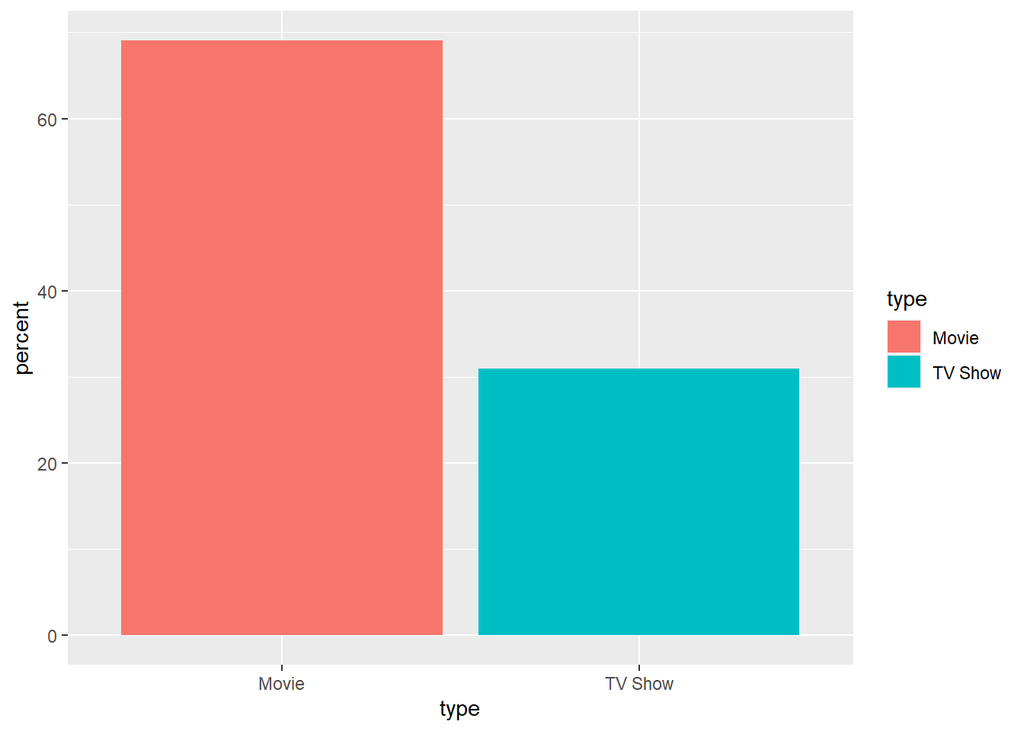

```r
netflix_titles %>% group_count("type") %>%
  mutate(percent = n / sum (n) * 100) %>%
  ggplot()+
  geom_col(aes(x = type, y = percent, fill = type))
```

Using helper function group_count can be used to see the most popular of any column

```r
netflix_titles$date_added <- mdy(netflix_titles$date_added)
netflix_countries_raw <- netflix_titles %>% group_count("country")
netflix_countries_raw
```

```
## # A tibble: 682 x 2
##    country            n
##    <chr>          <int>
##  1 United States   2555
##  2 India            923
##  3 <NA>             507
##  4 United Kingdom   397
##  5 Japan            226
##  6 South Korea      183
##  7 Canada           177
##  8 Spain            134
##  9 France           115
## 10 Egypt            101
## # ... with 672 more rows
```

Multiple countries exist, I split them into separate rows by country

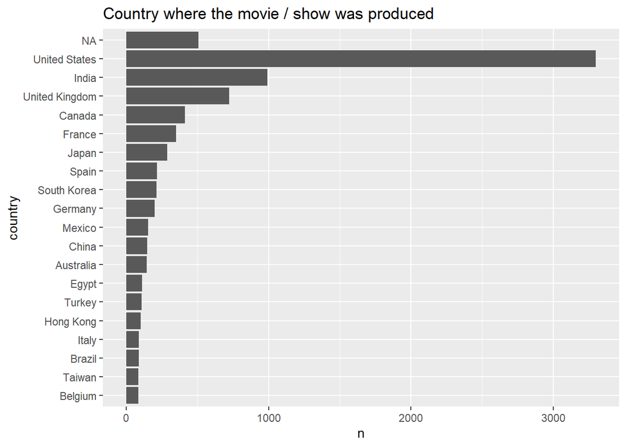

```r
netflix2 <- separate_rows(netflix_titles, country, sep = ", ")

netflix2 %>%
  group_count("country") %>%
  head(20) %>%
  ggplot(aes(x = fct_reorder(country, n), y = n))+
  geom_col()+
  coord_flip()+
  labs(title = "Country where the movie / show was produced",
      x = "country")
```

Some series has NA in the country, which is weird because everything has to be filmed SOMEWHERE right?

```r
na_country <- netflix2 %>% filter(is.na(country))
na_country
```

```
## # A tibble: 507 x 12
##    show_id type  title director cast  country date_added release_year rating
##    <chr>   <chr> <chr> <chr>    <chr> <chr>   <date>            <dbl> <chr>
##  1 s17     TV S~ Feb-~ <NA>     Shah~ <NA>    2019-03-20         2018 TV-14
##  2 s39     TV S~ แผนร~ <NA>     Chut~ <NA>    2019-03-30         2016 TV-14
##  3 s68     Movie 13TH~ <NA>     Opra~ <NA>    2017-01-26         2017 <NA>
##  4 s98     Movie 3 De~ Nagesh ~ Nase~ <NA>    2019-12-31         2003 TV-MA
##  5 s118    Movie 5 Co~ Anggy U~ Ario~ <NA>    2019-01-05         2017 TV-MA
##  6 s142    TV S~ 7SEE~ <NA>     Nao ~ <NA>    2020-03-26         2020 TV-MA
##  7 s179    Movie A Go~ Alex Wo~ Alan~ <NA>    2020-10-02         2020 TV-Y
##  8 s180    Movie A Go~ Stanley~ Alan~ <NA>    2020-08-04         2020 TV-Y
##  9 s205    Movie A Mi~ Ahmad E~ Edwa~ <NA>    2019-04-25         2012 TV-MA
## 10 s243    Movie A Tr~ Eddie R~ Henr~ <NA>    2020-12-11         2020 TV-Y
## # ... with 497 more rows, and 3 more variables: duration <chr>,
## #   listed_in <chr>, description <chr>
```

Using separate_rows and group_count for directors

```r
separate_rows(netflix_titles, director, sep = ", ") %>%
  group_count("director")
```

```
## # A tibble: 4,479 x 2
##    director                n
##    <chr>               <int>
##  1 <NA>                 2389
##  2 Jan Suter              21
##  3 Raúl Campos            19
##  4 Marcus Raboy           16
##  5 Jay Karas              15
##  6 Cathy Garcia-Molina    13
##  7 Jay Chapman            12
##  8 Martin Scorsese        12
##  9 Youssef Chahine        12
## 10 Steven Spielberg       10
## # ... with 4,469 more rows
```

```r
na_directors <- netflix_titles %>% filter(is.na(director))
```

a LOT of missing info for directors (and the dataset as a whole) for some reason

EDA while keeping NA values:

```r
# data set that only contains at least 1 NA
netflix_titles_na <- netflix_titles %>% filter(!complete.cases(netflix_titles))
colSums(is.na(netflix_titles_na))
```

```
##      show_id         type        title     director         cast      country
##            0            0            0         2389          718          507
##   date_added release_year       rating     duration    listed_in  description
##           10            0            7            0            0            0
```

Here we see how the NA values are spread out

Using data with NA filtered out

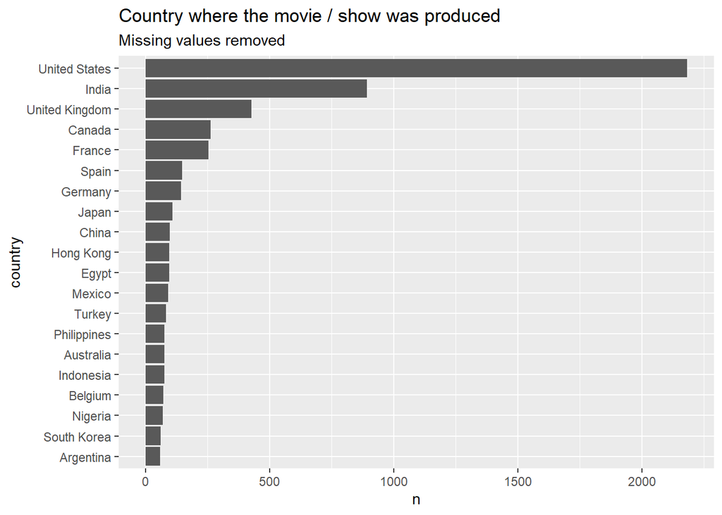

```r
netflix2 %>% filter(complete.cases(netflix2)) %>%
  group_count("country") %>%
  head(20) %>%
 ggplot()+
   geom_col(aes(x = fct_reorder(country, n), y = n))+
   coord_flip()+
   labs(title = "Country where the movie / show was produced",
       x = "country",
       subtitle = "Missing values removed")
```

Interesting takeaways: Canada jumps to the 4th spot after removing any row with missing values Japan and South Korea which were the previous 4th and 5th most popular country has dropped

```r
netflix_JPSK <- netflix_titles %>%
                filter(country == "Japan" | country == "South Korea") %>%
                filter(!complete.cases(.))

colSums(is.na(netflix_JPSK))
```

```
##      show_id         type        title     director         cast      country
##            0            0            0          287            7            0
##   date_added release_year       rating     duration    listed_in  description
##            1            0            1            0            0            0
```

For Japanese and South Korean titles, most missing values are in the director column.

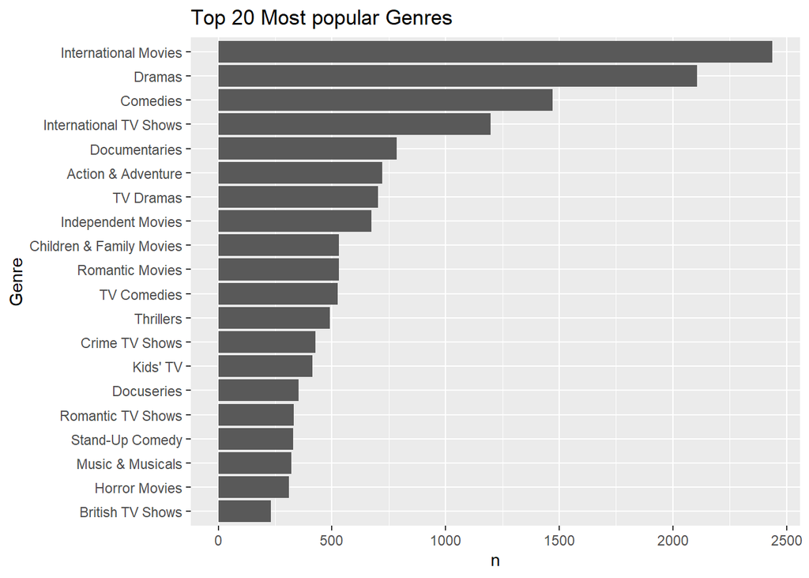

```r
netflix_titles %>%
  separate_rows(listed_in, sep = ", ") %>%
  group_count("listed_in") %>%
  head(20) %>%
  ggplot()+
  geom_col(aes(x = fct_reorder(listed_in, n), y = n))+
  coord_flip()+
  labs(title = "Top 20 Most popular Genres",
      x = "Genre")
```

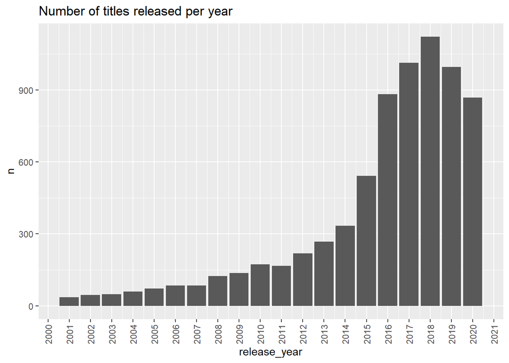

```r
netflix_titles %>%
  group_count("release_year") %>%
  head(20) %>%
  ggplot()+
  geom_col(aes(x = release_year, y = n))+
  scale_x_continuous(n.breaks = 20)+
  theme(axis.text.x = element_text(angle = 90, vjust = 0.5))+
  labs(title = "Number of titles released per year")
```

[figure not shown]

```r
timediff <- netflix_titles %>%
            mutate(timediff = year(date_added) - release_year) %>%
            select(title, date_added, release_year, timediff)

ggplot(timediff, aes(x = release_year, y = timediff, color = release_year))+
  geom_point()+
  labs(title = "Time it takes for something to get added to Netflix",
       y = "Days to get added to Netflix")
```

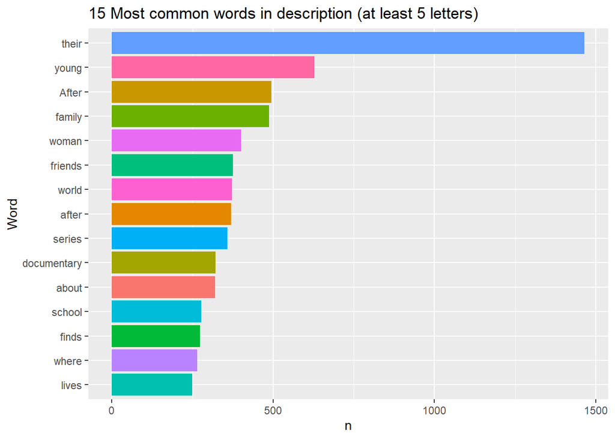

```r
x <- netflix_titles$description %>%
  str_split(boundary("word")) %>%
  unlist() %>%
  str_extract("^.{5,}") %>%
  as_tibble()

x <- x %>%  filter(!is.na(x))

rename(x, word = value) %>%
  group_count("word") %>%
  head(15) %>%
  ggplot()+
  geom_col(aes(x = fct_reorder(word, n), y = n, fill = word))+
  coord_flip()+
  labs(title = "15 Most common words in description (at least 5 letters)",
       x = "Word")+
  theme(legend.position = "")
```

```r
countrydata <- function(df, input){

  newdf <- df %>%
            filter(country == input)

top_genres <- newdf %>%
              separate_rows(listed_in, sep = ", ") %>%
              group_count("listed_in") %>%
              head(15) %>%
              ggplot()+
              geom_col(aes(x = fct_reorder(listed_in, n), y = n))+
              coord_flip()+
              labs(title = "Top 20 Most Popular Genres based on film location",
                    x = "Genre",
                   subtitle = input)


top_directors <- newdf %>%
              filter(!is.na(newdf$director)) %>%
              separate_rows(director, sep = ", ") %>%
              group_count("director") %>%
              head(15) %>%
              ggplot()+
              geom_col(aes(x = fct_reorder(director, n), y = n))+
              coord_flip()+
              labs(title = "Top directors",
                    x = "director",
                   subtitle = input)

print(top_genres)
print(top_directors)

}
```

An example of the above function:

[figure not shown]

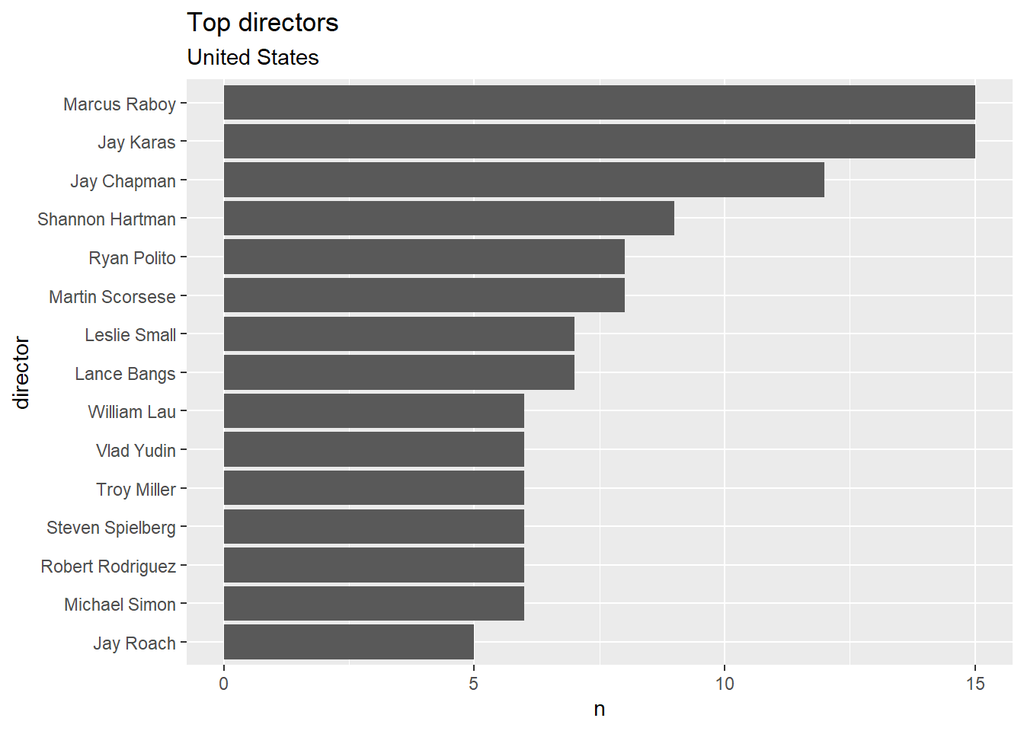

```r
netflix_titles %>%
  countrydata("United States")
```

Looking at different trends between countries I will use the country column as the country of origin of the show, although it may not be entirely accurate as films can be shot in one country but with a different director

```r
netflix_movies <- netflix_titles %>% filter(type == "Movie")

netflix_movies$duration <- str_replace(netflix_movies$duration, "\\smin", replacement = "") #Removes min from duration column
netflix_movies$duration <- as.double(netflix_movies$duration)


netflix_movies %>%
  filter(!is.na(netflix_movies$country)) %>%
  separate_rows(country, sep = ", ") %>%
  group_by(country) %>%
  summarise(n = n(), median_duration = median(duration, na.rm = TRUE)) %>%
  arrange(desc(n))
```

```
## # A tibble: 114 x 3
##    country            n median_duration
##    <chr>          <int>           <dbl>
##  1 United States   2430              93
##  2 India            915             127
##  3 United Kingdom   466              97
##  4 Canada           286              92
##  5 France           265              98
##  6 Spain            158             101
##  7 Germany          157              99
##  8 Japan            103              98
##  9 China            102             105
## 10 Mexico           101              92
## # ... with 104 more rows
```

```r
netflix_movies %>% separate_rows(listed_in, sep = ", ") %>%
  group_by(listed_in) %>%
  summarise(n = n(), median_duration = median(duration, na.rm = TRUE)) %>%
  arrange(desc(median_duration))
```

```
## # A tibble: 20 x 3
##    listed_in                    n median_duration
##    <chr>                    <int>           <dbl>
##  1 Classic Movies             103           112
##  2 Dramas                    2106           109
##  3 Action & Adventure         721           108
##  4 International Movies      2437           107
##  5 Music & Musicals           321           107
##  6 Romantic Movies            531           106
##  7 Faith & Spirituality        57           105
##  8 Thrillers                  491           103
##  9 Sci-Fi & Fantasy           218           102
## 10 Comedies                  1471           101
## 11 Cult Movies                 59            99
## 12 Independent Movies         673            98
## 13 Anime Features              57            96
## 14 Sports Movies              196            95.5
## 15 Horror Movies              312            94
## 16 LGBTQ Movies                90            94
## 17 Children & Family Movies   532            87
## 18 Documentaries              786            86
## 19 Stand-Up Comedy            329            65
## 20 Movies                      56            44.5
```